# Projekt do předmětu Časové řady I

- Zobrazit celý kód
- Skrýt celý kód
- Zobrazit zdrojový kód

Autor

Michal Červenka, Martin Heger, Štěpán Husa

Publikováno

15. prosince 2025

# Úvod

## 1. Načtení knihoven

**Kód**

```r
# Načtení potřebných balíčků
if (!require(forecast)) install.packages("forecast", repos = "https://cloud.r-project.org")
if (!require(zoo)) install.packages("zoo")
if (!require(readr)) install.packages("readr", repos = "https://cloud.r-project.org")
if (!require(tseries)) install.packages("tseries", repos = "https://cloud.r-project.org")
library(readr)
library(zoo)
library(forecast)
library(tseries)
library(ggplot2)
library(dplyr)
library(tseries)
```

## 2. Načtení dat

**Kód**

```r
# Načtení datasetu
data <- read_csv("MLTollsStackOverflow.csv")
head(data[c("month", "python", "r")])
```

```
# A tibble: 6 × 3
  month  python     r
  <chr>   <dbl> <dbl>
1 09-Jan    631     8
2 09-Feb    633     9
3 09-Mar    766     4
4 09-Apr    768    12
5 09-May   1003     2
6 09-Jun   1046     5
```

## 3. Popis dat

Použitý dataset obsahuje měsíční počty dotazů na StackOverflow od roku 2009 do roku 2020 pro různé programovací knihovny a technologie. Pro účely této analýzy se zaměřujeme pouze na dvě proměnné – Python a R, které reprezentují počet dotazů souvisejících s těmito jazyky v jednotlivých měsících.

Nejprve jsme si zobrazili několik prvních pozorování datasetu, abychom se seznámili se strukturou dat a ověřili, že hodnoty odpovídají očekávanému formátu. Následně jsme vypočítali základní popisné statistiky pro obě časové řady.

### Popisné statistiky - Python & R

**Kód**

```r
# Popisné statistiky
summary(data[, c("python", "r")])
```

```
     python            r
 Min.   :  631   Min.   :   2.0
 1st Qu.: 3744   1st Qu.: 608.8
 Median : 9652   Median :2613.5
 Mean   : 9857   Mean   :2411.9
 3rd Qu.:15591   3rd Qu.:4000.5
 Max.   :23602   Max.   :5138.0
```

- Minimální počet dotazů je výrazně vyšší u Pythonu než u R.
- Medián i průměr jsou u Pythonu několikanásobně vyšší než u R, což naznačuje dlouhodobě větší popularitu Pythonu.
- Rozptyl hodnot je u Pythonu rovněž vyšší, což souvisí s rychlejším růstem zájmu v čase.
- Maximální hodnoty ukazují, že Python dosahuje až téměř 24 000 dotazů za měsíc, zatímco R přibližně 5 100.

# Analýza

## 1. Předběžný výzkum časové řady

### Grafické zobrazení časových řad

#### Python

**Kód**

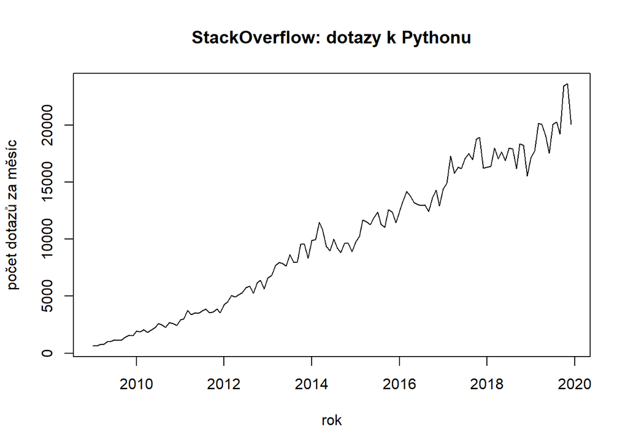

```r
# Vytvoření časové řady: Python
python_ts <- ts(data$python,
                start = c(2009, 1),
                #end = c(2015, 12),
                frequency = 12)

# Vytvoření časové řady: R
r_ts <- ts(data$r,
           start = c(2009, 1),
           #end = c(2015, 12),
           frequency = 12)

# Graf: Python
plot(python_ts,
     main = "StackOverflow: dotazy k Pythonu",
     ylab = "počet dotazů za měsíc",
     xlab = "rok")
```

- Jasný rostoucí trend od roku 2009 do 2020.
- Postupem času narůstá i variabilita počtu dotazů.
- Viditelné pravidelné sezónní kolísání.

#### R

**Kód**

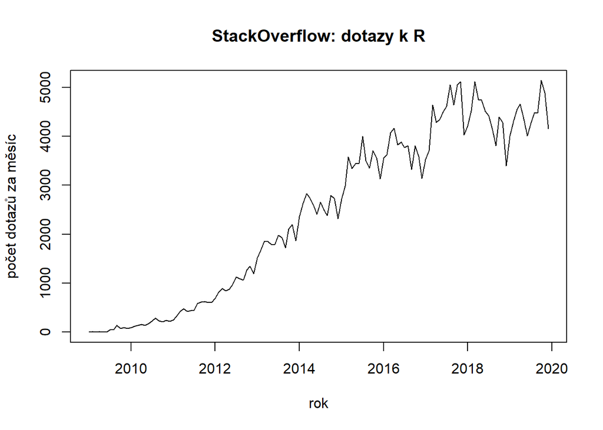

```r
# Graf: R
plot(r_ts,
     main = "StackOverflow: dotazy k R",
     ylab = "počet dotazů za měsíc",
     xlab = "rok")
```

- Trend také roste, ale pomaleji a méně výrazně než u Pythonu.
- Amplituda sezónnosti je menší.
- Po roce 2017 se růst zpomaluje.

#### Společný graf

**Kód**

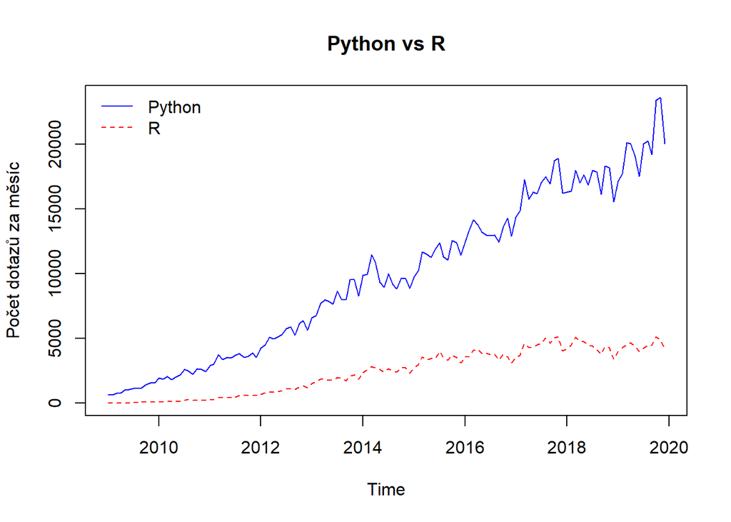

```r
# Společný graf
par(mfrow = c(1,1))


ts.plot(cbind(python_ts, r_ts),
        col = c("blue", "red"),
        lty = 1:2,
        main = "Python vs R",
        ylab = "Počet dotazů za měsíc")

legend("topleft",
       legend = c("Python", "R"),
       col = c("blue", "red"),
       lty = 1:2,
       bty = "n")
```

- Python má výrazně větší počet dotazů a rychleji roste.
- Od roku ~2014 se rozdíl ještě zvětšuje.
- Oba jazyky mají podobný vzor sezónnosti.

### Aditivní dekompozice

#### Python

**Kód**

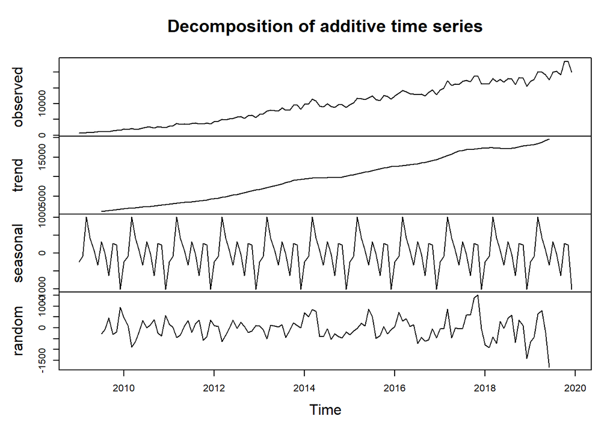

```r
# Additivní dekompozice

## Python
decomp_python <- decompose(python_ts, type = "additive")
plot(decomp_python)
```

- **Trend**: silně rostoucí, plynulý.
- **Sezónnost**: pravidelná, opakující se ročně.
- **Remainder**: náhodné fluktuace bez jasné struktury.

## 2. Testování stacionarity

### Python

**Kód**

```r
adf_python <- adf.test(python_ts)
adf_python
```

```
    Augmented Dickey-Fuller Test

data:  python_ts
Dickey-Fuller = -3.1904, Lag order = 5, p-value = 0.09258
alternative hypothesis: stationary
```

### Python - odmocina

**Kód**

```r
adf_python_diff <- adf.test(sqrt(python_ts))
adf_python_diff
```

```
    Augmented Dickey-Fuller Test

data:  sqrt(python_ts)
Dickey-Fuller = -2.2222, Lag order = 5, p-value = 0.4841
alternative hypothesis: stationary
```

### Python - odmocnina a diferencování

**Kód**

```r
adf_r_diff  <- adf.test(diff(sqrt(python_ts)))
adf_r_diff
```

```
    Augmented Dickey-Fuller Test

data:  diff(sqrt(python_ts))
Dickey-Fuller = -5.9475, Lag order = 5, p-value = 0.01
alternative hypothesis: stationary
```

**Shrnutí**:

- Časová řada je nestacionární v původní podobě.
- Důvodem je především rostoucí trend a možná sezónnost.
- Časová řada se stává stacionární po jedné diferenci a odmocninové transformaci.
- Pro modelování ARIMA bude nutné řady diferencovat (parametr d = 1).

## 3. Autokorelace a parciální autokorelace

### Python

**Kód**

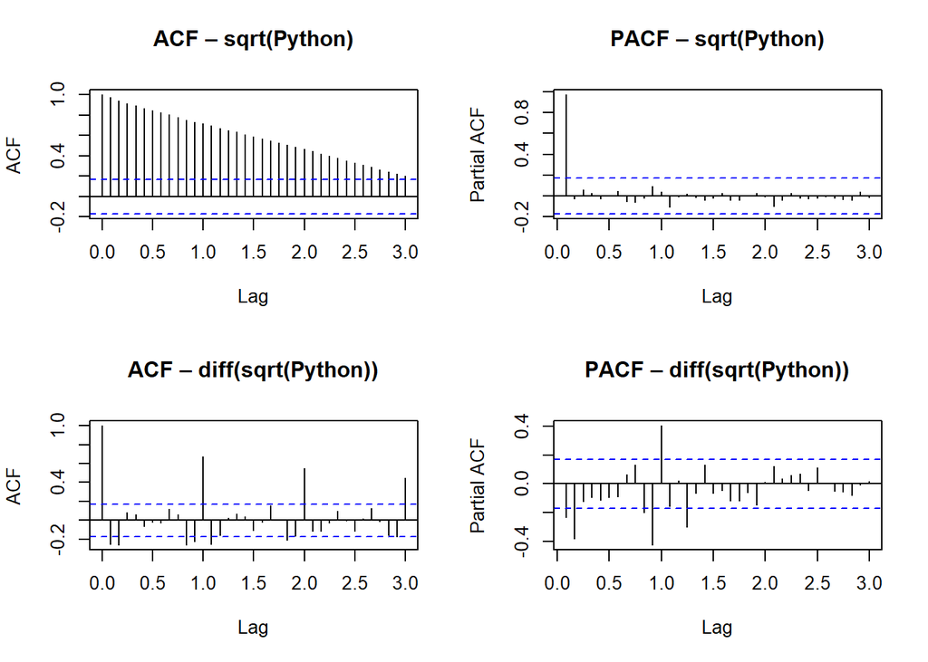

```r
par(mfrow = c(2,2))

acf(sqrt(python_ts), main = "ACF – sqrt(Python)",lag.max = 36)
pacf(sqrt(python_ts), main = "PACF – sqrt(Python)",lag.max = 36)

acf(diff(sqrt(python_ts)), main = "ACF – diff(sqrt(Python))",lag.max = 36)
pacf(diff(python_ts), main = "PACF – diff(sqrt(Python))",lag.max = 36)
```

**Shrnutí**:

- exponenciální pokles acf, pacf nevýznamná po prvním lagu -> AR(1)
- řada je stacionární po první diferenci naznačuje ARIMA(1, 1, 0)

## 4. Výběr vhodných modelů

**Kód**

```r
print("boxcox lambda")
```

```
[1] "boxcox lambda"
```

**Kód**

```r
BoxCox.lambda(python_ts)
```

```
[1] 0.4195015
```

**Kód**

```r
python_log<-sqrt(python_ts)
```

**Kód**

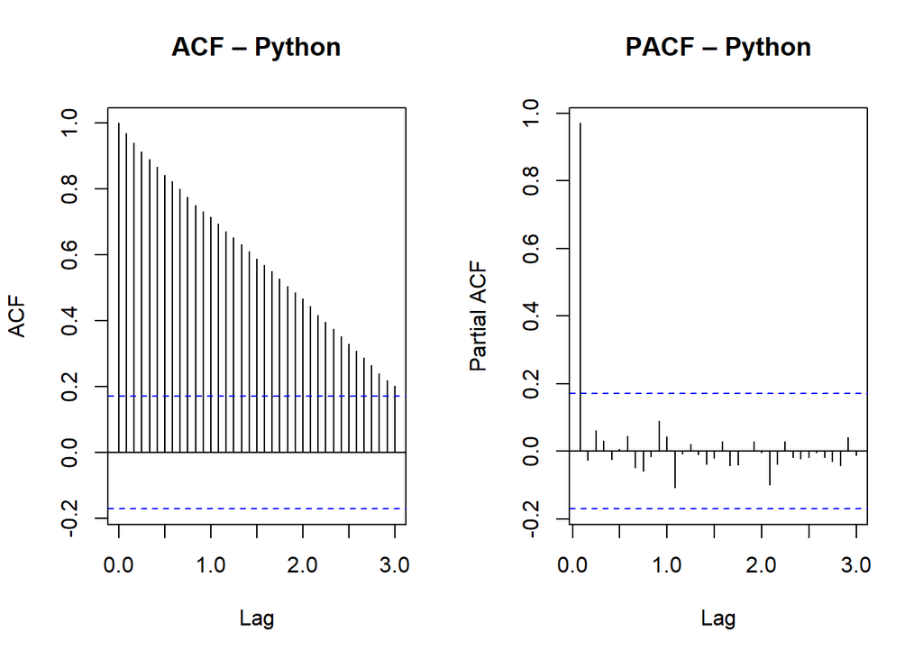

```r
par(mfrow = c(1,2))

acf(python_log, main = "ACF – Python",lag.max = 36)
pacf(python_log, main = "PACF – Python",lag.max = 36)
```

**Kód**

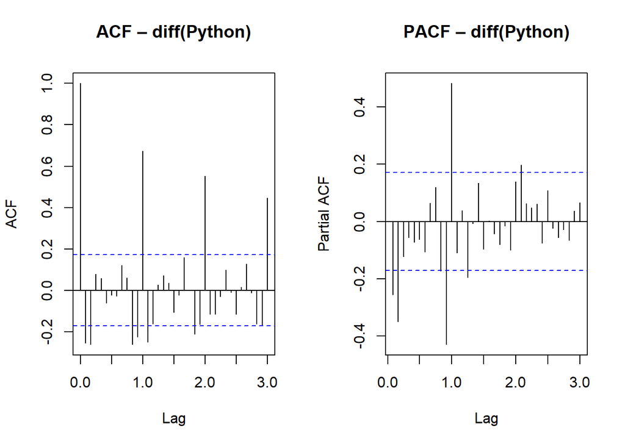

```r
par(mfrow = c(1,2))
acf(diff(python_log), main = "ACF – diff(Python)",lag.max = 36)
pacf(diff(python_log), main = "PACF – diff(Python)",lag.max = 36)
```

**Kód**

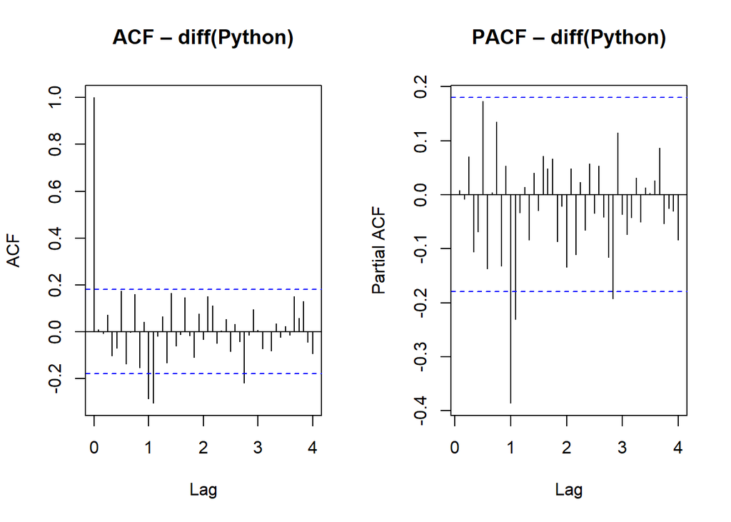

```r
par(mfrow = c(1,2))
acf(diff(diff(python_log),lag=12), main = "ACF – diff(Python)",lag.max = 48)
pacf(diff(diff(python_log),lag=12), main = "PACF – diff(Python)",lag.max = 48)
```

**Odůvodnění volby parametrů modelu SARIMA**

Na základě vizuální analýzy ACF a PACF odmocněné řady, zdiferencované řady, sezoně zdiferencované řady a předchozí dekompozice jsme stanovili parametry pro výchozí model ve tvaru $SARIMA(p,d,q)(P,D,Q)_{[12]}$.

- Trend ($d=1$):

  Původní časová řada vykazovala jasný rostoucí trend a nestacionaritu, což potvrdil i Augmented Dickey-Fullerův test (p-hodnota $< 0.05$ po diferenciaci). Aplikace první diference tento trend úspěšně odstranila. Graf ACF diferencované řady navíc ukazuje na lagu 1 a 2 významné záporné hodnoty, což je v literatuře považováno za varovný signál proti dalšímu diferencování (riziko tzv. over-differencing). Z tohoto důvodu fixujeme řád diferenciace na $d=1$.
- Sezónnost ($D=1$):

  Analýza sezónních lagů (12, 24, 36) odhalila poměrně nejasnou strukturu. Jak ACF tak i PACF vykazují na lagu 12 silnou zápornou autokorelaci a poté se na lazích 24 a dál odstřihnou. Při detailnějším pohledu však vidíme jasné ustřižení na ACF na lagu 24 a spíše pozvolné doznívání sezoních lazích u PACF. Zvolíme proto Q=1 a podrobíme model dalším testům.

**Výsledný startovací model:** $SARIMA(0,1,1)(0,1,1)_{[12]}$

**Poznámka k riziku:** Jsme si vědomi hrozby redundance parametrů (tzv. *parameter cancellation*), která hrozí u takto specifikovaných smíšených modelů. Tento model slouží jako výchozí bod a v další fázi analýzy budeme testovat statistickou významnost jednotlivých koeficientů s cílem model zjednodušit (zejména v nesezónní části).

## 5. Optimalizace modelu

Nyní tento model odhadneme a provedeme testování statistické významnosti jeho koeficientů. Naším cílem je najít nejjednodušší možný model , proto zkontrolujeme, zda jsou všechny parametry skutečně potřeba.

**Kód**

```r
# Odhad modelu SARIMA(0,1,1)(0,1,1)[12]
# Volba q=2 vychází z pozorování ACF (lag 1, 2)
fit_manual <- Arima(python_log,
                    order = c(0, 1, 1),
                    seasonal = c(0, 1, 1))

print("=== ANALÝZA KOEFICIENTŮ (Startovací model) ===")
```

```
[1] "=== ANALÝZA KOEFICIENTŮ (Startovací model) ==="
```

**Kód**

```r
print(fit_manual)
```

```
Series: python_log
ARIMA(0,1,1)(0,1,1)[12]

Coefficients:
          ma1     sma1
      -0.1103  -0.4844
s.e.   0.1001   0.1031

sigma^2 = 6.513:  log likelihood = -280.94
AIC=567.89   AICc=568.1   BIC=576.22
```

**Kód**

```r
# Test významnosti parametrů nového modelu
t_stat_d2 <- fit_manual$coef / sqrt(diag(fit_manual$var.coef))
print(data.frame(Koeficient = names(fit_manual$coef),
                 t_statistika = t_stat_d2,
                 Vyznamny = abs(t_stat_d2) > 1.96))
```

```
     Koeficient t_statistika Vyznamny
ma1         ma1    -1.102125    FALSE
sma1       sma1    -4.699447     TRUE
```

**Kód**

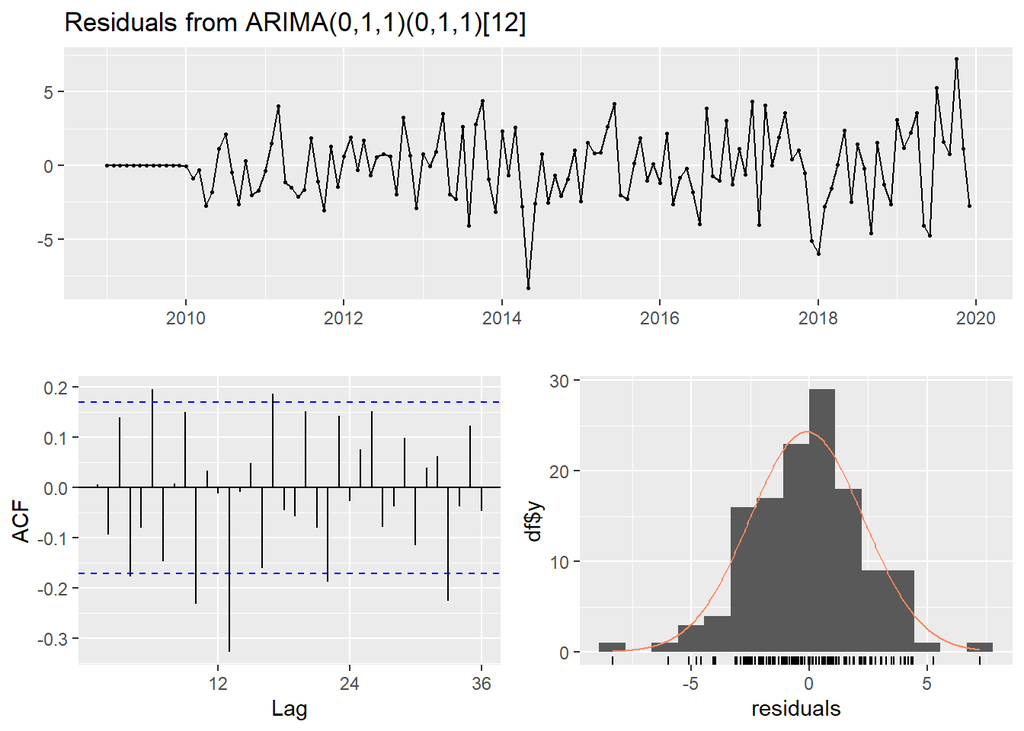

```
    Ljung-Box test

data:  Residuals from ARIMA(0,1,1)(0,1,1)[12]
Q* = 68.598, df = 22, p-value = 1.097e-06

Model df: 2.   Total lags used: 24
```

```r
checkresiduals(fit_manual)
```

### Redukce modelu na základě statistické významnosti

V souladu s touto analýzou odstraňujeme nevýznamný parametr $ma1$ a definujeme náš finální manuální model ve tvaru $SARIMA(0,1,0)(0,1,1)_{[12]}$.

**Kód**

```r
# Finální manuální model (po redukci nevýznamných parametrů)
# Odstraňujeme ma2 (q=2 -> q=1)
# Stále držíme d=2, protože to vyžaduje trend
fit_manual_final <- Arima(python_log,
                          order = c(0, 1, 0),
                          seasonal = c(0, 1,1 ))

print("=== FINÁLNÍ MANUÁLNÍ MODEL (0,1,0)(0,1,1) ===")
```

```
[1] "=== FINÁLNÍ MANUÁLNÍ MODEL (0,1,0)(0,1,1) ==="
```

**Kód**

```r
print(fit_manual_final)
```

```
Series: python_log
ARIMA(0,1,0)(0,1,1)[12]

Coefficients:
         sma1
      -0.4627
s.e.   0.1070

sigma^2 = 6.539:  log likelihood = -281.53
AIC=567.06   AICc=567.16   BIC=572.61
```

**Kód**

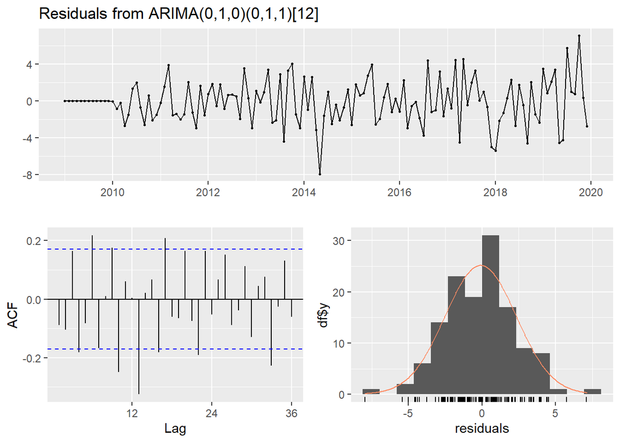

```
    Ljung-Box test

data:  Residuals from ARIMA(0,1,0)(0,1,1)[12]
Q* = 81.601, df = 23, p-value = 1.745e-08

Model df: 1.   Total lags used: 24
```

```r
# Finální kontrola reziduí
checkresiduals(fit_manual_final)
```

Pro kontrolu správnosti našeho úsudku nyní necháme algoritmus `auto.arima` (který minimalizuje informační kritérium AICc), aby nalezl optimální model automaticky, a následně jej porovnáme.

**Kód**

```r
# Automatický návrh (s důrazem na prohledání prostoru)
fit_auto <- auto.arima(python_log, seasonal = TRUE, stepwise = FALSE, approximation = FALSE)

print("=== AUTO ARIMA NÁVRH ===")
```

```
[1] "=== AUTO ARIMA NÁVRH ==="
```

**Kód**

```r
print(fit_auto)
```

```
Series: python_log
ARIMA(4,1,0)(0,1,1)[12]

Coefficients:
          ar1      ar2     ar3      ar4    sma1
      -0.0609  -0.1329  0.1480  -0.1841  -0.543
s.e.   0.0904   0.0934  0.0928   0.0930   0.092

sigma^2 = 6.159:  log likelihood = -276.69
AIC=565.38   AICc=566.13   BIC=582.06
```

**Kód**

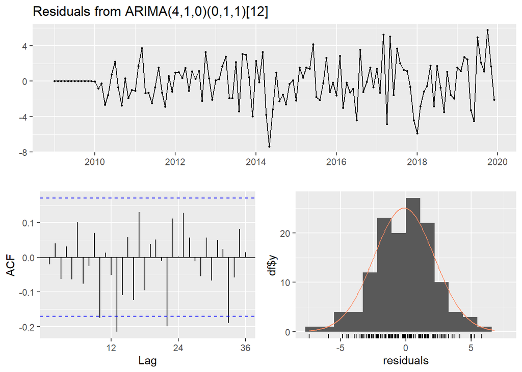

```
    Ljung-Box test

data:  Residuals from ARIMA(4,1,0)(0,1,1)[12]
Q* = 33.976, df = 19, p-value = 0.0185

Model df: 5.   Total lags used: 24
```

```r
checkresiduals(fit_auto)
```

**Kód**

```r
# Srovnání AICc
# Pozor: Porovnáváme náš finální manuální model (fit_manual_final) s automatem
srovnani <- data.frame(
  Model = c("Náš manuální (0,1,0)(0,1,1)", "Auto ARIMA návrh","Náš manuální (0,1,1)(0,1,1)"),
  AICc = c(fit_manual_final$aicc, fit_auto$aicc,fit_manual$aicc)
)
print(srovnani)
```

```
                        Model     AICc
1 Náš manuální (0,1,0)(0,1,1) 567.1595
2            Auto ARIMA návrh 566.1312
3 Náš manuální (0,1,1)(0,1,1) 568.0950
```

Algoritmus `auto.arima` identifikoval model, který dosahuje o 1 bod menšího informačního kritéria (AICc). Box test také zamítá hypotézu o nezávislých reziduích. Pro finální predikci přesto volíme náš manualní model se statisticky nevýznamným horším AICc a dáváme přednost jeho jednoduchosti.

**Kód**

```r
final_model <- fit_manual_final
```

## 6. Diagnostika modelu

Předtím, než model použijeme k predikci, musíme ověřit, zda jeho rezidua (chyby) splňují předpoklady “bílého šumu”. Zkontrolujeme:

- Zda rezidua nevykazují autokorelaci (podstatná informace nezůstala v datech).
- Zda mají normální rozdělení.

**Kód**

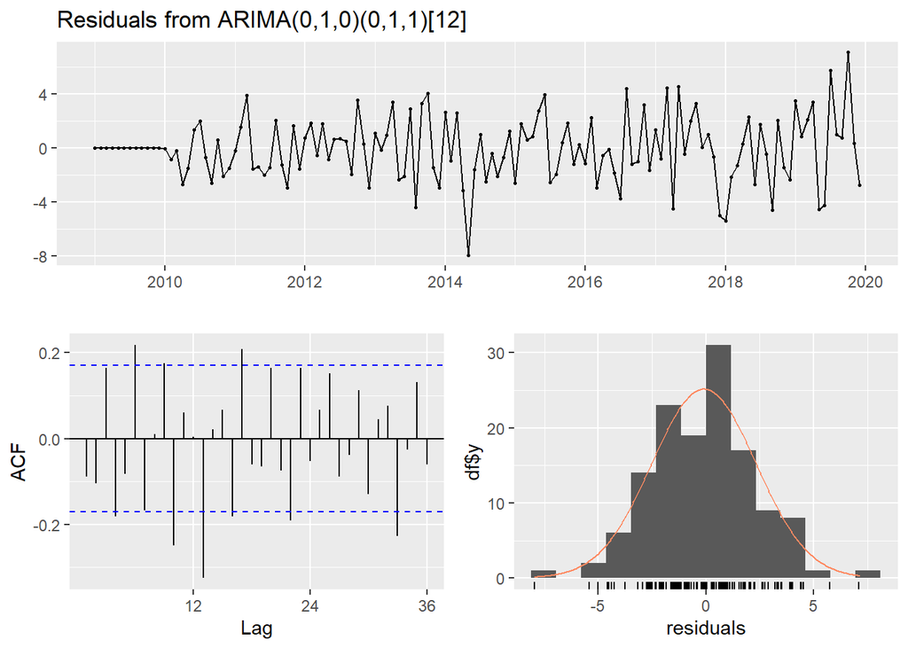

```
    Ljung-Box test

data:  Residuals from ARIMA(0,1,0)(0,1,1)[12]
Q* = 81.601, df = 23, p-value = 1.745e-08

Model df: 1.   Total lags used: 24
```

```r
# Grafická diagnostika
checkresiduals(final_model)
```

## 7. Predikce

Provedeme predikci na 12 měsíců dopředu. Je nutné provést zpětnou transformaci (omocnění), protože model pracoval s odmocninami.

**Kód**

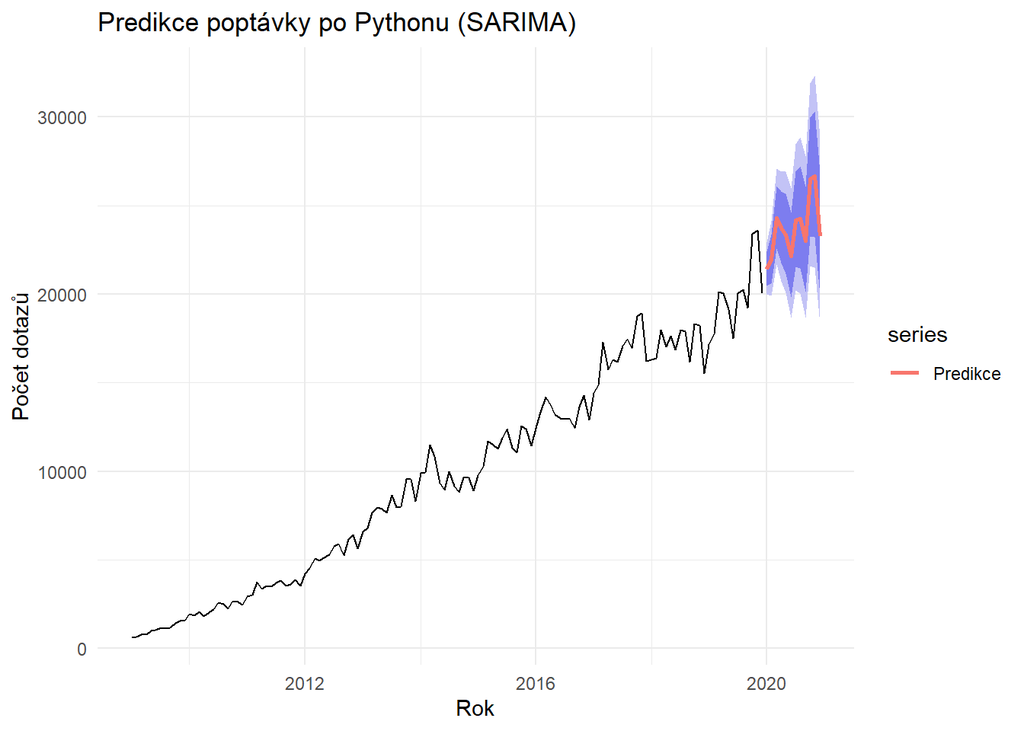

```r
# 1. Predikce v odmocnine
forecast_log <- forecast(final_model, h = 12)

# 2. Zpětná transformace (exp)
forecast_orig <- forecast_log
forecast_orig$mean  <- (forecast_log$mean)^2
forecast_orig$lower <- (forecast_log$lower)^2
forecast_orig$upper <- (forecast_log$upper)^2
forecast_orig$x     <- (forecast_log$x)^2

# 3. Vykreslení
autoplot(forecast_orig) +
  autolayer(forecast_orig$mean, series = "Predikce", size = 1) +
  labs(title = "Predikce poptávky po Pythonu (SARIMA)",
       y = "Počet dotazů",
       x = "Rok") +
  theme_minimal()
```

**Kód**

```r
# Výpis hodnot
print(head(forecast_orig$mean, 12))
```

```
          Jan      Feb      Mar      Apr      May      Jun      Jul      Aug
2020 21430.45 21960.25 24314.44 23731.74 23364.57 22159.28 24154.95 24250.52
          Sep      Oct      Nov      Dec
2020 22998.05 26501.26 26647.02 23261.46
```

### Validace modelu – predikce posledních 24 měsíců

Kromě predikce do budoucna je užitečné ověřit, jak dobře model dokáže zpětně předpovědět známá data. Proto odstraníme posledních 24 měsíců z časové řady, na zbytku znovu natrénujeme SARIMA model a následně se pokusíme predikovat právě těchto 24 měsíců.

Tuto „pseudo-predikci“ poté porovnáme se skutečnými hodnotami. Pokud je model správně nastavený, měl by zachytit alespoň základní trend a sezónní průběh, i když krátkodobé výkyvy se mohou lišit.

**Kód**

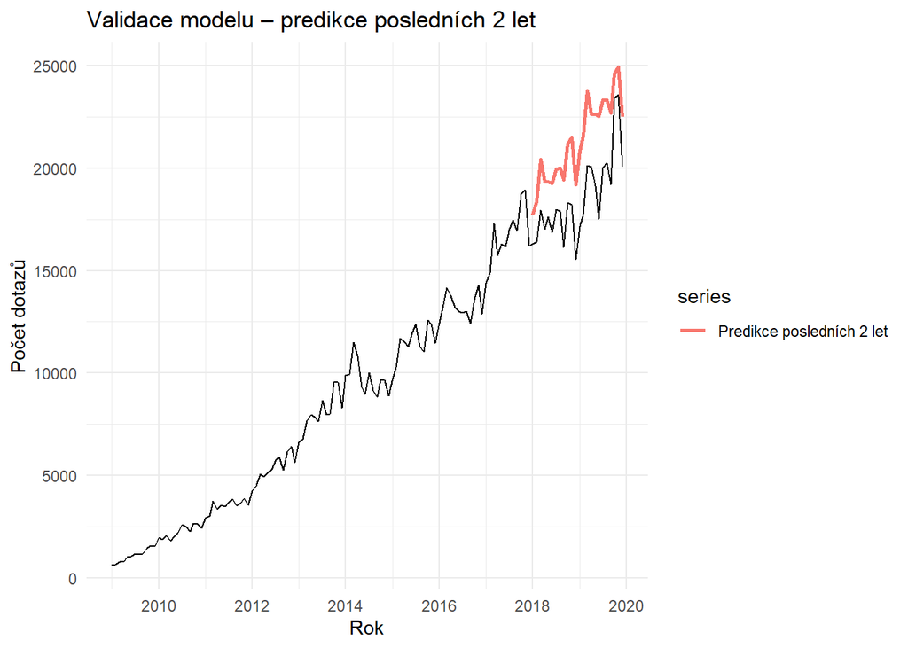

```r
h <- 24

n <- length(python_log)
python_log_train <- head(python_log, n - h)
python_log_test  <- tail(python_log, h)

# stejný typ modelu jako final_model, znovu odhadnutý na zkrácené řadě
model_train <- Arima(python_log_train, model = final_model)

# predikce posledníhch 2 let v odmocnine a zpětná transformace
forecast_log_oos  <- forecast(model_train, h = h)
forecast_oos_mean <- (forecast_log_oos$mean)^2

# graf: celá řada + predikce posledních 2 let
autoplot((python_log)^2) +
  autolayer(forecast_oos_mean, series = "Predikce posledních 2 let", size = 1) +
  labs(title = "Validace modelu – predikce posledních 2 let",
       y = "Počet dotazů",
       x = "Rok") +
  theme_minimal()
```

# Závěr

## Diskuze

- **Omezení modelu:** Hlavním limitem modelu je zamítnutí hypotézy o nezávislosti reziduí (Ljung-Boxův test). To naznačuje, že model nedokázal plně absorbovat veškerou strukturu dat, pravděpodobně v důsledku strukturálního zlomu v popularitě Pythonu kolem roku 2017 a přítomnosti heteroskedasticity (změny rozptylu), kterou odmocninová transformace odstranila jen částečně. Model je tedy vhodný pro bodovou predikci trendu, ale intervaly spolehlivosti mohou být mírně podhodnocené.
- **Možnosti vylepšení:** Přesnost modelu by mohla být zvýšena zkrácením časové řady (např. použitím dat pouze od roku 2015), čímž by se eliminoval vliv staršího, odlišného chování trendu. Dále by bylo možné využít pokročilejší modely odolné vůči strukturálním zlomům, jako je např. Prophet, nebo zahrnout exogenní proměnné (např. počet pracovních dní v měsíci).

## Závěrečné poznámky

Projekt ukazuje postup od přípravy dat až po modelování a predikci pomocí metod ARIMA a jejich variant.